# Clustering and Dimensionality Reduction Demo

Mikhail Dozmorov

# # 1. Load Data

In this section, we read the NCI-60 dataset and inspect its structure. https://dctd.cancer.gov/drug-discovery-development/assays/high-throughput-screening-services/nci60

```r
mtx <- read.delim(
  "/Users/mdozmorov/Documents/Work/Teaching/BIOS658.2025/static/slides/09_Clustering/data/nci60.tsv",
  sep = "\t", row.names = 1
)
dim(mtx)
```

```
## [1] 5244   61
```

```r
colnames(mtx)
```

```
##  [1] "CNS"      "CNS.1"    "CNS.2"    "RENAL"    "BREAST"   "CNS.3"
##  [7] "CNS.4"    "BREAST.1" "NSCLC"    "NSCLC.1"  "RENAL.1"  "RENAL.2"
## [13] "RENAL.3"  "RENAL.4"  "RENAL.5"  "RENAL.6"  "RENAL.7"  "BREAST.2"
## [19] "NSCLC.2"  "RENAL.8"  "OVAR"     "MELA"     "OVAR.1"   "OVAR.2"
## [25] "OVAR.3"   "OVAR.4"   "OVAR.5"   "NSCLC.3"  "NSCLC.4"  "NSCLC.5"
## [31] "LEUK"     "K562B.re" "K562A.re" "LEUK.1"   "LEUK.2"   "LEUK.3"
## [37] "LEUK.4"   "LEUK.5"   "COLON"    "COLON.1"  "COLON.2"  "COLON.3"
## [43] "COLON.4"  "COLON.5"  "COLON.6"  "MCF7A.re" "BREAST.3" "MCF7D.re"
## [49] "BREAST.4" "NSCLC.6"  "NSCLC.7"  "NSCLC.8"  "MELA.1"   "BREAST.5"
## [55] "BREAST.6" "MELA.2"   "MELA.3"   "MELA.4"   "MELA.5"   "MELA.6"
## [61] "MELA.7"
```

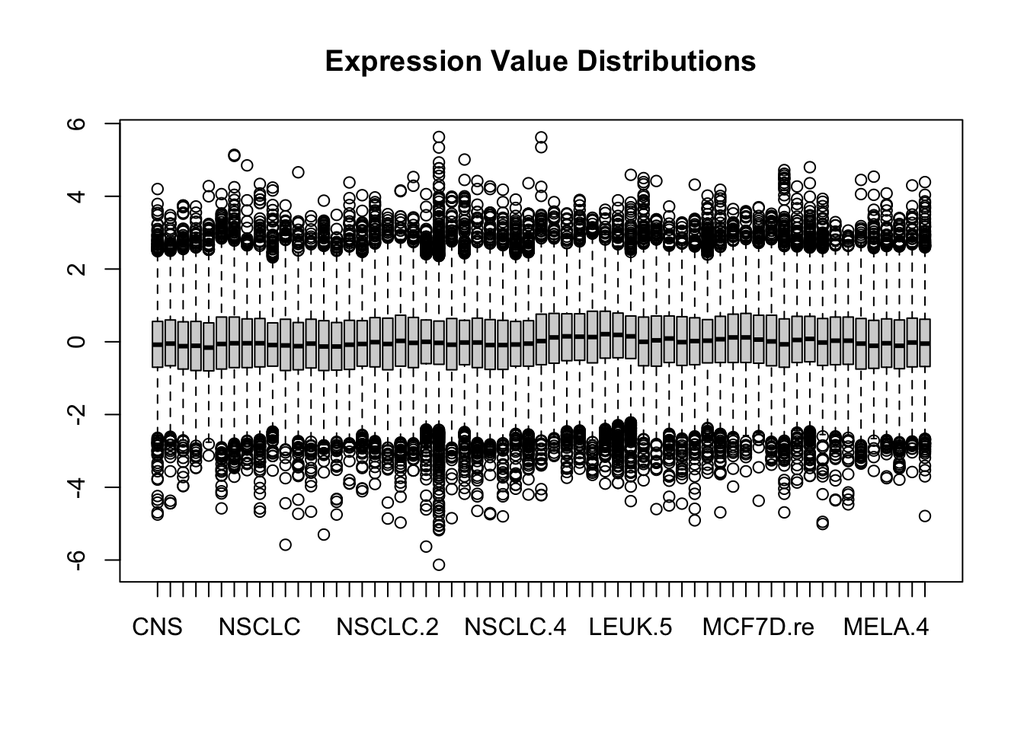

```r
boxplot(mtx, main = "Expression Value Distributions")
```

# # 2. Create Sample Annotations

```r
groups <- sapply(colnames(mtx), function(x){
  obj <- strsplit(x, ".", fixed = TRUE)
  unlist(obj)[1]
})

groups[ groups %in% c("K562A","K562B") ] <- "K562"
groups[ groups %in% c("MCF7A","MCF7D") ] <- "MCF7"

table(groups)
```

```
## groups
## BREAST    CNS  COLON   K562   LEUK   MCF7   MELA  NSCLC   OVAR  RENAL
##      7      5      7      2      6      2      8      9      6      9
```

# # 3. PCA (Principal Component Analysis)

We perform PCA on the scaled data and examine variance explained.

```r
pca <- prcomp(scale(t(mtx)))
summary(pca)$importance[,1:5] %>% pander
```

|  | PC1 | PC2 | PC3 | PC4 | PC5 |
| --- | --- | --- | --- | --- | --- |
| **Standard deviation** | 25.05 | 19.45 | 16.74 | 14.81 | 13.58 |
| **Proportion of Variance** | 0.1197 | 0.07217 | 0.05343 | 0.04185 | 0.03515 |
| **Cumulative Proportion** | 0.1197 | 0.1919 | 0.2453 | 0.2871 | 0.3223 |

```r
str(pca)
```

```
## List of 5
##  $ sdev    : num [1:61] 25.1 19.5 16.7 14.8 13.6 ...
##  $ rotation: num [1:5244, 1:61] 0.01001 0.00184 0.00162 -0.00613 0.0013 ...
##   ..- attr(*, "dimnames")=List of 2
##   .. ..$ : chr [1:5244] "GENE6683X" "GENE2811X" "GENE3496X" "GENE4158X" ...
##   .. ..$ : chr [1:61] "PC1" "PC2" "PC3" "PC4" ...
##  $ center  : Named num [1:5244] -9.10e-18 -2.67e-17 1.82e-17 1.09e-17 -1.46e-17 ...
##   ..- attr(*, "names")= chr [1:5244] "GENE6683X" "GENE2811X" "GENE3496X" "GENE4158X" ...
##  $ scale   : Named num [1:5244] 1 1 1 1 1 ...
##   ..- attr(*, "names")= chr [1:5244] "GENE6683X" "GENE2811X" "GENE3496X" "GENE4158X" ...
##  $ x       : num [1:61, 1:61] 21.1 21.6 32.4 36.3 40.1 ...
##   ..- attr(*, "dimnames")=List of 2
##   .. ..$ : chr [1:61] "CNS" "CNS.1" "CNS.2" "RENAL" ...
##   .. ..$ : chr [1:61] "PC1" "PC2" "PC3" "PC4" ...
##  - attr(*, "class")= chr "prcomp"
```

`prcomp()` returns a list with five main components. Here’s what each represents.

- **`sdev` — Standard Deviations of Principal Components**
  - A numeric vector of length = number of PCs.
  - Each value is the **standard deviation** of a principal component.
  - Larger = more variance explained by that PC.

Square them to get eigenvalues: $\lambda_i = \text{sdev}_i^2$

The proportion of variance explained:

```r
(sdev^2) / sum(sdev^2)
```

- **`rotation` — Loadings (Eigenvectors)**
  - A **matrix of gene loadings**:
    - **Rows = variables (genes)**
    - **Columns = principal components (PC1…PC61)**
  - Values represent how much each gene contributes to a PC.
  - These are the **eigenvectors** of the covariance/correlation matrix.
  - High absolute value = gene strongly influences that PC.
- **`center` — Means Used for Centering**
  - A named vector of gene-wise means.
  - Each gene was mean-centered before PCA: $x_{ij}' = x_{ij} - \text{center}_i$
- **`scale` — Scaling Factors (if `scale=TRUE`)**
  - Contains **gene-wise scaling constants**.
  - In other words: $x' = \frac{x - \text{center}}{\text{scale}}$
  - If `scale=FALSE`, this component is `NULL`.
- **`x` — Principal Component Scores**
  - A matrix of **transformed coordinates** (scores) in PC space.
    - Rows = samples
    - Columns = PC1…PC61
  - These are the coordinates you plot.
  - `x[i, j]` = the position of sample *i* on PC *j*.
  - They are computed as: $X_\text{scores} = X_\text{centered} \cdot \text{rotation}$

# # 4. PCA Visualization with ggplot2

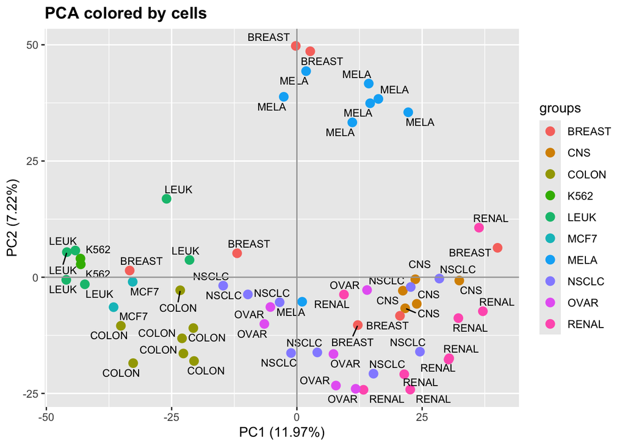

```r
colorby <- "cells"

pt <- ggplot(
  data = data.frame(pca$x, cells = groups, samples = groups),
  aes(x = PC1, y = PC2, label = samples)
) +
  theme(plot.title = element_text(face = "bold")) +
  ggtitle(paste("PCA colored by", colorby)) +
  geom_point(aes(color = groups), size = 3) +
  geom_text_repel(size = 3) +
  geom_hline(yintercept = 0, color = "gray65") +
  geom_vline(xintercept = 0, color = "gray65") +
  scale_x_continuous(
    name = paste0("PC1 (", round(summary(pca)$importance[2,1]*100, 2), "%)")
  ) +
  scale_y_continuous(
    name = paste0("PC2 (", round(summary(pca)$importance[2,2]*100, 2), "%)")
  )

pt
```

# # 5. Additional PCA Visualizations

## ggord

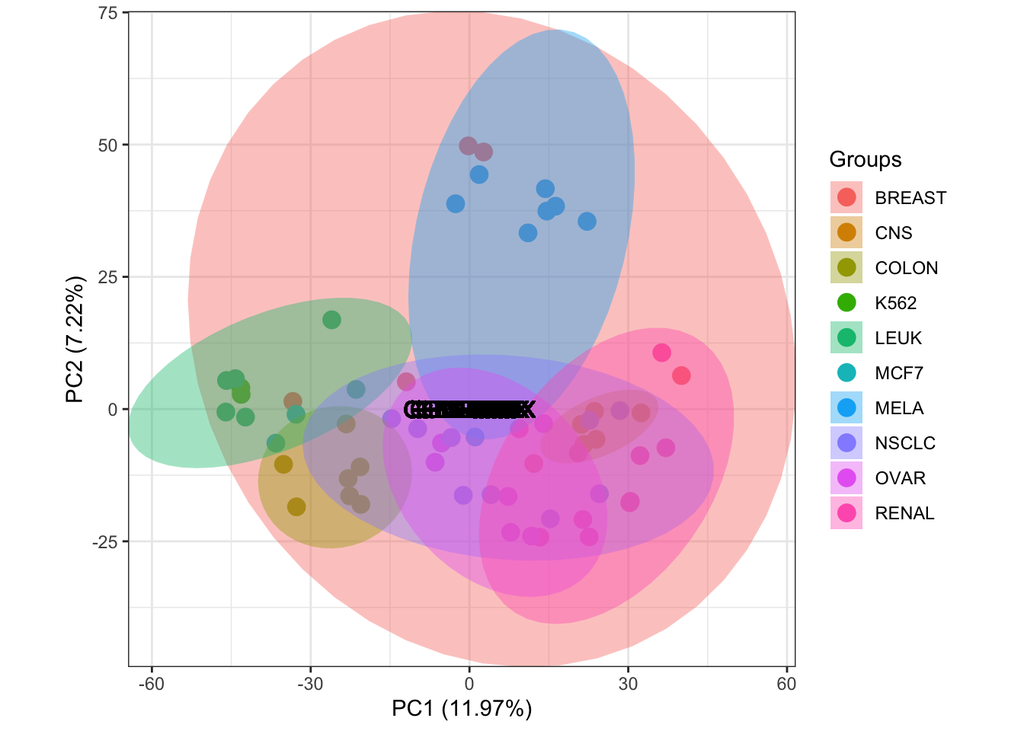

```r
library(ggord)
ggord(pca, groups, arrow = NULL)
```

## ggfortify

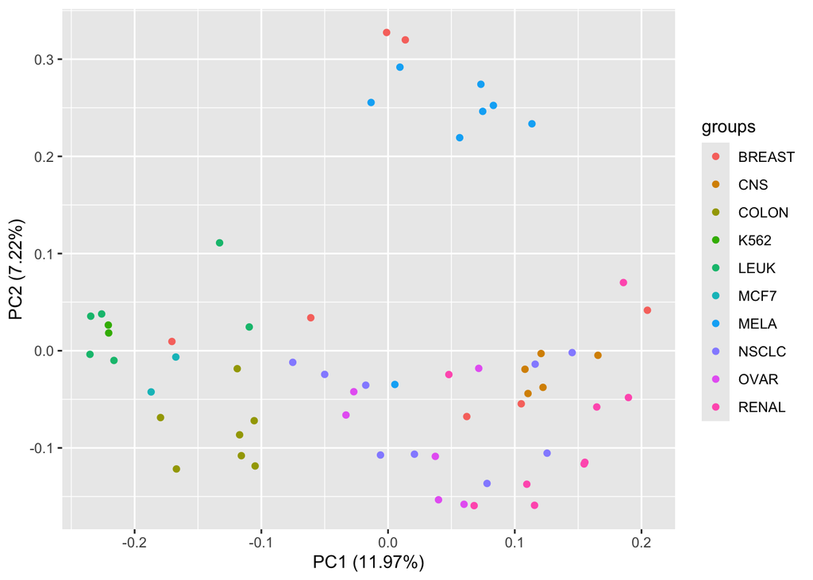

```r
library(ggfortify)
autoplot(
  prcomp(scale(t(mtx))),
  data = data.frame(groups = groups),
  colour = "groups"
)
```

# # 6. Add Artificial Batch Effect

We artificially square half of the samples to simulate batch effects.

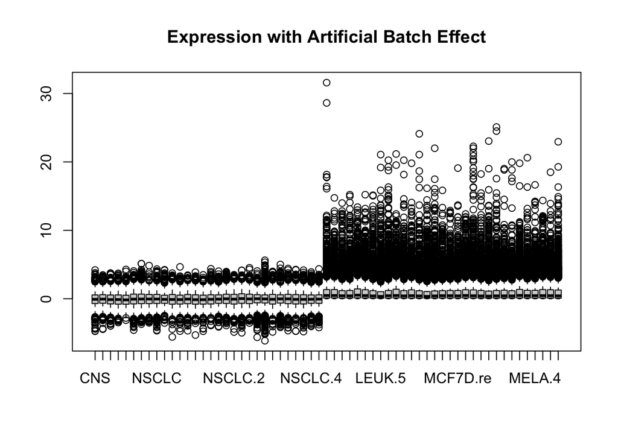

```r
mtx_with_batch <- cbind(
  mtx[, 1:round(ncol(mtx) / 2)],
  mtx[, (round(ncol(mtx) / 2) + 1):ncol(mtx)]^2
)
boxplot(mtx_with_batch, main = "Expression with Artificial Batch Effect")
```

```r
batch <- c(rep(1, round(ncol(mtx)/2)), rep(2, ncol(mtx) - round(ncol(mtx)/2)))
batch
```

```
##  [1] 1 1 1 1 1 1 1 1 1 1 1 1 1 1 1 1 1 1 1 1 1 1 1 1 1 1 1 1 1 1 2 2 2 2 2 2 2 2
## [39] 2 2 2 2 2 2 2 2 2 2 2 2 2 2 2 2 2 2 2 2 2 2 2
```

# # 7. PCA with Batch Effect

```r
pca <- prcomp(t(scale(mtx_with_batch)))
summary(pca)$importance[,1:5] %>% pander
```

|  | PC1 | PC2 | PC3 | PC4 | PC5 |
| --- | --- | --- | --- | --- | --- |
| **Standard deviation** | 15.8 | 15.33 | 14.62 | 13.91 | 13.48 |
| **Proportion of Variance** | 0.04813 | 0.04528 | 0.04119 | 0.03729 | 0.03502 |
| **Cumulative Proportion** | 0.04813 | 0.09341 | 0.1346 | 0.1719 | 0.2069 |

### Visualization

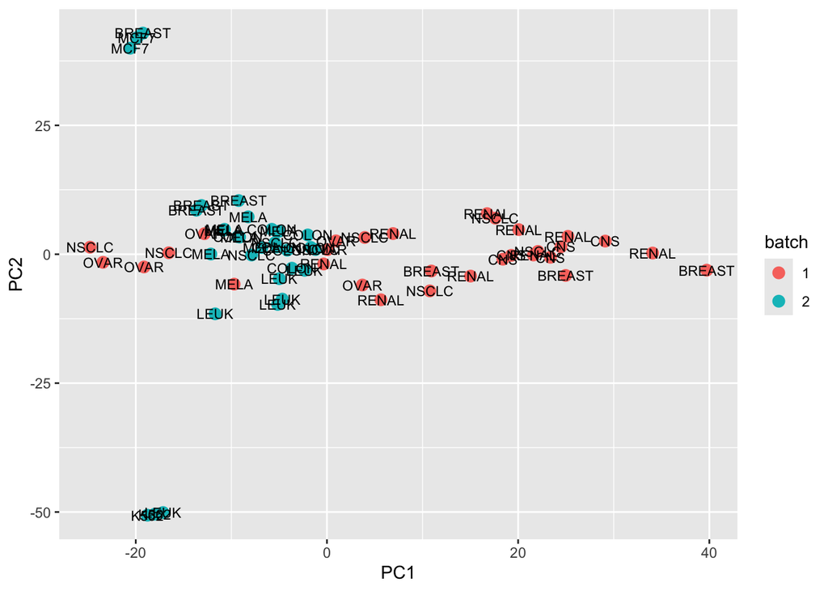

```r
ggplot(
  data = data.frame(pca$x, cells = groups, samples = groups,
                    batch = factor(batch)),
  aes(x = PC1, y = PC2, label = samples)
) +
  geom_point(aes(color = batch), size = 3) +
  geom_text(size = 3)
```

# # 8. Which Covariate Explains PCs?

We test how strongly the batch variable associates with PC1–PC3.

```r
lmp <- function(modelobject){
  f <- summary(modelobject)$fstatistic
  p <- pf(f[1], f[2], f[3], lower.tail = FALSE)
  attributes(p) <- NULL
  p
}

covariates <- c("batch")

for (covariate in covariates){
  df <- data.frame(batch = batch, pca$x)

  for (pc in c("PC1","PC2","PC3")){
    model <- lm(as.numeric(df[[pc]]) ~ factor(df[[covariate]]))
    rsq <- signif(summary(model)$adj.r.squared, 5)
    pv  <- signif(lmp(model), 5)
    print(paste(covariate, "explains", rsq, "of", pc, "p-value", pv))
  }
}
```

```
## [1] "batch explains 0.35193 of PC1 p-value 2.8222e-07"
## [1] "batch explains -0.016783 of PC2 p-value 0.92213"
## [1] "batch explains -0.006913 of PC3 p-value 0.44623"
```

# # 9. MDS (Multidimensional Scaling)

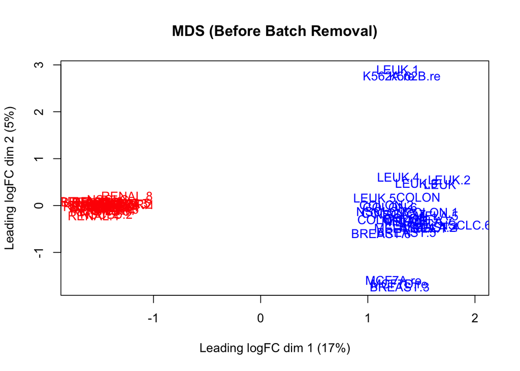

```r
plotMDS(
  mtx_with_batch,
  col = ifelse(batch == 1, "red", "blue"),
  main = "MDS (Before Batch Removal)"
)
```

# # 10. t-SNE

```r
library(Rtsne)

tsne <- Rtsne(
  (scale(t(mtx))),
  dims = 2,
  perplexity = 20,
  verbose = TRUE,
  max_iter = 500
)
```

```
## Performing PCA
## Read the 61 x 50 data matrix successfully!
## Using no_dims = 2, perplexity = 20.000000, and theta = 0.500000
## Computing input similarities...
## Building tree...
## Done in 0.00 seconds (sparsity = 0.983607)!
## Learning embedding...
## Iteration 50: error is 53.837079 (50 iterations in 0.00 seconds)
## Iteration 100: error is 55.901960 (50 iterations in 0.00 seconds)
## Iteration 150: error is 53.315193 (50 iterations in 0.00 seconds)
## Iteration 200: error is 55.352412 (50 iterations in 0.00 seconds)
## Iteration 250: error is 55.316131 (50 iterations in 0.00 seconds)
## Iteration 300: error is 1.540285 (50 iterations in 0.00 seconds)
## Iteration 350: error is 1.113548 (50 iterations in 0.00 seconds)
## Iteration 400: error is 1.033850 (50 iterations in 0.00 seconds)
## Iteration 450: error is 0.856921 (50 iterations in 0.00 seconds)
## Iteration 500: error is 0.715258 (50 iterations in 0.00 seconds)
## Fitting performed in 0.01 seconds.
```

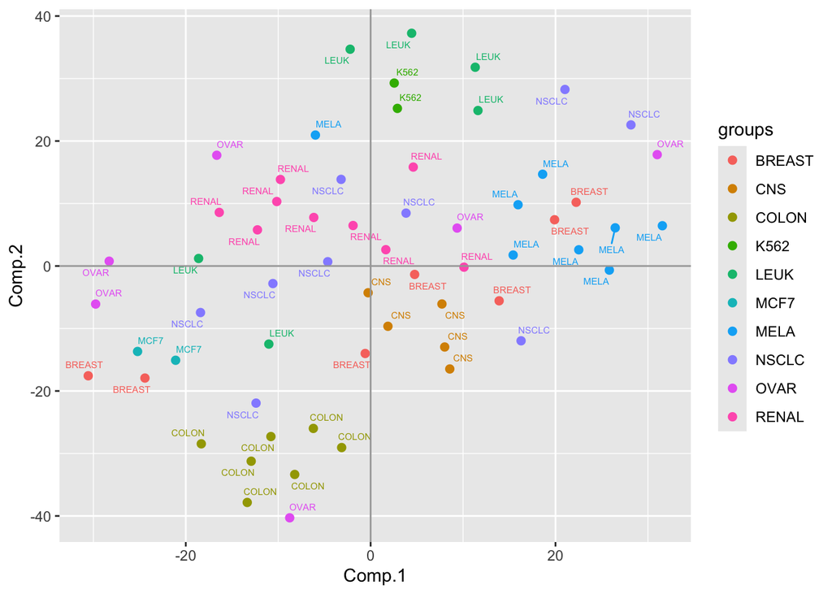

```r
colors <- rainbow(length(unique(groups)))

scores <- as.data.frame(tsne$Y)
rownames(scores) <- colnames(mtx)
colnames(scores) <- c("Comp.1", "Comp.2")
scores$groups <- groups

ggplot(scores, aes(x = Comp.1, y = Comp.2,
                   label = groups, color = groups)) +
  geom_point(size = 2) +
  geom_text_repel(size = 2) +
  geom_hline(yintercept = 0, color = "gray65") +
  geom_vline(xintercept = 0, color = "gray65") +
  theme(plot.title = element_text(face="bold"))
```

# # 11. 3D PCA + Animated GIF

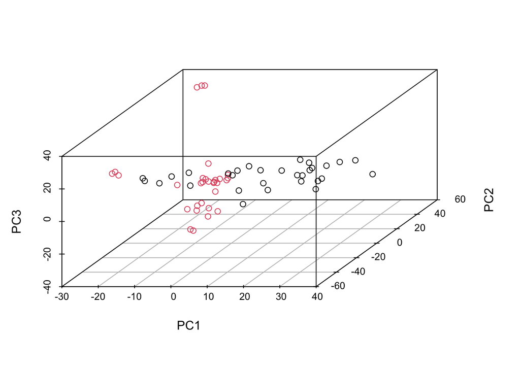

```r
scores <- as.data.frame(pca$x)

scatterplot3d(
  scores[,c("PC1","PC2","PC3")],
  color = as.numeric(factor(batch))
)
```

### Optional: Rotation Frames for GIF (Mac/Linux)

```r
rename <- function(i){
  if (i < 10)  return(paste0("000", i, "plot.png"))
  if (i < 100) return(paste0("00",  i, "plot.png"))
  paste0("0", i, "plot.png")
}

frames <- 360
for (i in 1:frames){
  name <- rename(i)
  png(name)
  s3d <- scatterplot3d(
    scores[,c("PC1","PC2","PC3")],
    main = paste("Angle", i),
    angle = i,
    pch = 19, cex.symbols = 0.5,
    color = as.numeric(factor(batch))
  )
  coords <- s3d$xyz.convert(scores[,c("PC1","PC2","PC3")])
  text(coords$x, coords$y, labels = groups, pos = 2, cex = 0.7)
  dev.off()
}

system('magick convert *.png -delay 1 -loop 0 3d.gif')
system("rm *.png")
```